# DOCUMENTO RESUMEN Caracterización Territorial Servicios Locales de Educación Pública Barrancas

Nota: Se consideran establecimientos en funcionamiento y con matrícula.  
Fuente: Cargos docentes 2021, Datos abiertos Mineduc.

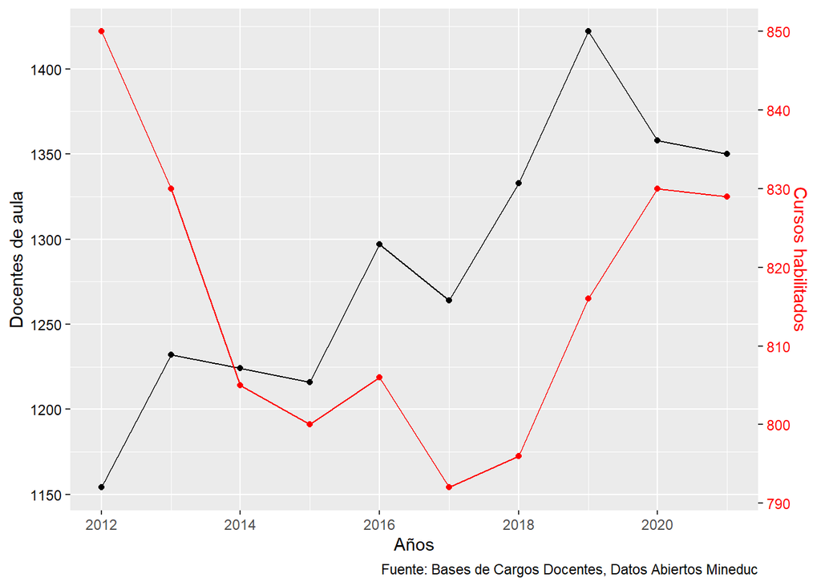

Figure 5.3: Evolución de docentes de aula municipales vs cursos habilitados

Table 5.5: Evolución de docentes municipales por tipo de contrato

| Tipo de Contrato | 2012 | 2013 | 2014 | 2015 | 2016 | 2017 | 2018 | 2019 | 2020 | 2021 |
| --- | --- | --- | --- | --- | --- | --- | --- | --- | --- | --- |
| Contratado | 576 | 639 | 652 | 559 | 556 | 622 | 731 | 863 | 788 | 768 |
| Contrato a Honorarios | 2 | 0 | 0 | 0 | 1 | 0 | 1 | 0 | 1 | 1 |
| Contrato PIE | 35 | 80 | 83 | 83 | 106 | 105 | 13 | 0 | 0 | 0 |
| Contrato SEP | 18 | 50 | 68 | 56 | 50 | 35 | 0 | 0 | 0 | 0 |
| Reemplazante | 22 | 22 | 26 | 28 | 34 | 22 | 30 | 36 | 12 | 35 |
| Titular | 837 | 772 | 684 | 780 | 848 | 784 | 860 | 872 | 888 | 903 |
| Total | 1.490 | 1.563 | 1.513 | 1.506 | 1.595 | 1.568 | 1.635 | 1.771 | 1.689 | 1.707 |

Nota: Se consideran establecimientos en funcionamiento y con matrícula.  
Fuente: Cargos docentes 2021, Datos abiertos Mineduc.

Table 5.6: Evolución en porcentaje de docentes municipales por tipo de contrato

| Tipo de Contrato | 2012 | 2013 | 2014 | 2015 | 2016 | 2017 | 2018 | 2019 | 2020 | 2021 |
| --- | --- | --- | --- | --- | --- | --- | --- | --- | --- | --- |
| Contratado | 38.66 | 40.88 | 43.09 | 37.12 | 34.86 | 39.67 | 44.71 | 48.73 | 46.65 | 44.99 |
| Contrato a Honorarios | 0.13 | 0.00 | 0.00 | 0.00 | 0.06 | 0.00 | 0.06 | 0.00 | 0.06 | 0.06 |
| Contrato PIE | 2.35 | 5.12 | 5.49 | 5.51 | 6.65 | 6.70 | 0.80 | 0.00 | 0.00 | 0.00 |
| Contrato SEP | 1.21 | 3.20 | 4.49 | 3.72 | 3.13 | 2.23 | 0.00 | 0.00 | 0.00 | 0.00 |
| Reemplazante | 1.48 | 1.41 | 1.72 | 1.86 | 2.13 | 1.40 | 1.83 | 2.03 | 0.71 | 2.05 |
| Titular | 56.17 | 49.39 | 45.21 | 51.79 | 53.17 | 50.00 | 52.60 | 49.24 | 52.58 | 52.90 |
| Total | 100.00 | 100.00 | 100.00 | 100.00 | 100.00 | 100.00 | 100.00 | 100.00 | 100.00 | 100.00 |

Nota: Se consideran establecimientos en funcionamiento y con matrícula.  
Fuente: Cargos docentes 2021, Datos abiertos Mineduc.

Table 5.7: Evolución de docentes municipales por horas de contrato

| Horas de Contrato | 2012 | 2013 | 2014 | 2015 | 2016 | 2017 | 2018 | 2019 | 2020 | 2021 |
| --- | --- | --- | --- | --- | --- | --- | --- | --- | --- | --- |
| 44 horas | 266 | 318 | 350 | 372 | 393 | 438 | 540 | 645 | 671 | 674 |
| Entre 22 y 32 horas | 516 | 523 | 493 | 452 | 468 | 383 | 307 | 302 | 253 | 246 |
| Entre 33 y 44 horas | 560 | 550 | 515 | 538 | 586 | 623 | 664 | 712 | 680 | 702 |
| Menos de 22 horas | 148 | 172 | 155 | 144 | 148 | 124 | 124 | 112 | 85 | 85 |
| Total | 1.490 | 1.563 | 1.513 | 1.506 | 1.595 | 1.568 | 1.635 | 1.771 | 1.689 | 1.707 |

Nota: Se consideran establecimientos en funcionamiento y con matrícula.  
Fuente: Cargos docentes 2021, Datos abiertos Mineduc.

Table 5.8: Evolución en porcentaje de docentes municipales por horas de contrato

| Horas de Contrato | 2012 | 2013 | 2014 | 2015 | 2016 | 2017 | 2018 | 2019 | 2020 | 2021 |
| --- | --- | --- | --- | --- | --- | --- | --- | --- | --- | --- |
| 44 horas | 17.85 | 20.35 | 23.13 | 24.70 | 24.64 | 27.93 | 33.03 | 36.42 | 39.73 | 39.48 |
| Entre 22 y 32 horas | 34.63 | 33.46 | 32.58 | 30.01 | 29.34 | 24.43 | 18.78 | 17.05 | 14.98 | 14.41 |
| Entre 33 y 44 horas | 37.58 | 35.19 | 34.04 | 35.72 | 36.74 | 39.73 | 40.61 | 40.20 | 40.26 | 41.12 |
| Menos de 22 horas | 9.93 | 11.00 | 10.24 | 9.56 | 9.28 | 7.91 | 7.58 | 6.32 | 5.03 | 4.98 |
| Total | 99.99 | 100.00 | 99.99 | 99.99 | 100.00 | 100.00 | 100.00 | 99.99 | 100.00 | 99.99 |

Nota: Se consideran establecimientos en funcionamiento y con matrícula.  
Fuente: Cargos docentes 2021, Datos abiertos Mineduc.

Table 5.9: Docentes municipales por Tramo de Carrera Docente, 2021

[output not shown]

Nota: Se consideran establecimientos en funcionamiento y con matrícula.  
Fuente: Cargos docentes 2021, Datos abiertos Mineduc.

- **Acceso**: Tramo provisorio donde se ubican los profesores que tienen 4 o más años de experiencia profesional, pero no cuentan con resultados vigentes en instrumentos de evaluación del Ministerio de Educación.
- **Inicial**: Es la etapa de inmersión en el ejercicio profesional.
- **Temprano**: Es la etapa de avance hacia la consolidación de las competencias profesionales, donde la enseñanza que se realiza evidencia un mayor desarrollo en todos sus aspectos.
- **Avanzado**: El docente consolida su identidad profesional, logrando un nivel esperado de los saberes y competencias profesionales, de acuerdo con los criterios señalados en el Marco para la Buena Enseñanza.
- **Experto I**: Tramo voluntario que da cuenta de un docente que cuenta con experiencia, competencias pedagógicas y conocimientos disciplinarios por sobre lo esperado para un buen ejercicio profesional docente.
- **Experto II**: Tramo voluntario y más alto de la Carrera Docente, que refiere a un profesor con experiencia, competencias pedagógicas y conocimientos disciplinarios de excelencia para el ejercicio profesional docente.

## 5.2 Asistentes de la Educación en el territorio

La definición de Asistentes de la Educación según el Artículo 2° de la Ley N° 21.109 Estatuto de los Asistentes de la Educación Pública corresponde a: *“**Son asistentes de la educación**, para efectos de esta ley, los funcionarios que, desempeñándose en uno o más establecimientos educacionales dependientes de los Servicios Locales de Educación Pública, sin perjuicio de su forma de financiamiento, incluidos aquellos establecimientos de educación parvularia financiados vía transferencia de fondos, colaboren en el desarrollo del proceso de enseñanza y aprendizaje de los estudiantes y la correcta prestación del servicio educacional, a través de funciones de carácter profesional”, además, “Se considerará asimismo asistente de la educación al personal que cumpla funciones en internados escolares que dependan de los servicios locales.”*